# Fitting distributions to dietary exposure data

Department of Epidemiology and Public Health, Sciensano, Belgium  
October 09, 2018  
https://github.com/brechtdv/fitdist

## Agenda

- Motivating example
- Individual observations
- Quantiles

## Motivating Example

## Motivating Example

What is the contribution of current red meat consumption levels to the colorectal cancer disease burden?

## Motivating Example

What is the contribution of current red meat consumption levels to the colorectal cancer disease burden?

**Comparative Risk Assessment**

Systematic evaluation of the changes in burden of disease which would result from modifying the population distribution of exposure to a **theoretical minimum risk exposure distribution (TMRED)** that would imply minimum health loss, keeping all other risk factors unchanged

Calculation of **Population Attributable Fraction**

\[PAF=\frac{\int{P(x)RR(x)dx}-\int{P'(x)RR(x)dx}}{\int{P(x)RR(x)dx}}\]

## Motivating Example

What is the contribution of current red meat consumption levels to the colorectal cancer disease burden?

**Comparative Risk Assessment**

Systematic evaluation of the changes in burden of disease which would result from modifying the population distribution of exposure to a **theoretical minimum risk exposure distribution (TMRED)** that would imply minimum health loss, keeping all other risk factors unchanged

Calculation of **Attributable Burden**

\[AB=B*PAF\]

## Motivating Example

What is the contribution of current red meat consumption levels to the colorectal cancer disease burden?

**Data requirements**

- Current disease burden of colorectal cancer
- Relative risk function
- Current red meat consumption levels
- Ideal consumption level (TMREL)

## Motivating Example

### Colorectal cancer disease burden

[figure not shown]

Institute for Health Metrics and Evaluation

Global Burden of Disease, 2016

- 8,863 new cases
- 3,725 deaths
- 57,283 DALYs

## Motivating Example

### Relative risk function

**Food groups and risk of colorectal cancer.** Schwingshackl L, Schwedhelm C, Hoffmann G, Knüppel S, Laure Preterre A, Iqbal K, Bechthold A, De Henauw S, Michels N, Devleesschauwer B, Boeing H, Schlesinger S. Int J Cancer. 2018 May 1;142(9):1748-1758. [doi: 10.1002/ijc.31198](https://doi.org/10.1002/ijc.31198)

Non-linear dose-response function

[dosresmeta](https://alecri.github.io/software/dosresmeta.html) package

## Motivating Example

### Relative risk function

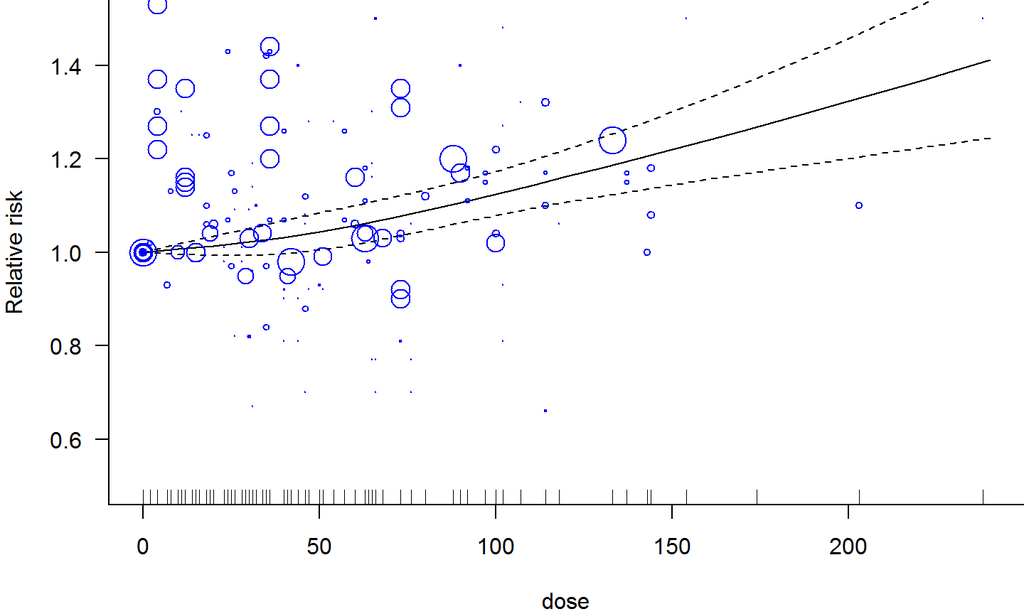

## Motivating Example

### Red meat consumption levels

FFQ and 24h recalls

- Statistical Program to Assess Dietary Exposure (SPADE)

Individual observations

- Bootstrap
- Method of moments
- Maximum likelihood

Quantiles

- Optimization

## Which distribution?

Main characteristic: non-negative, continuous

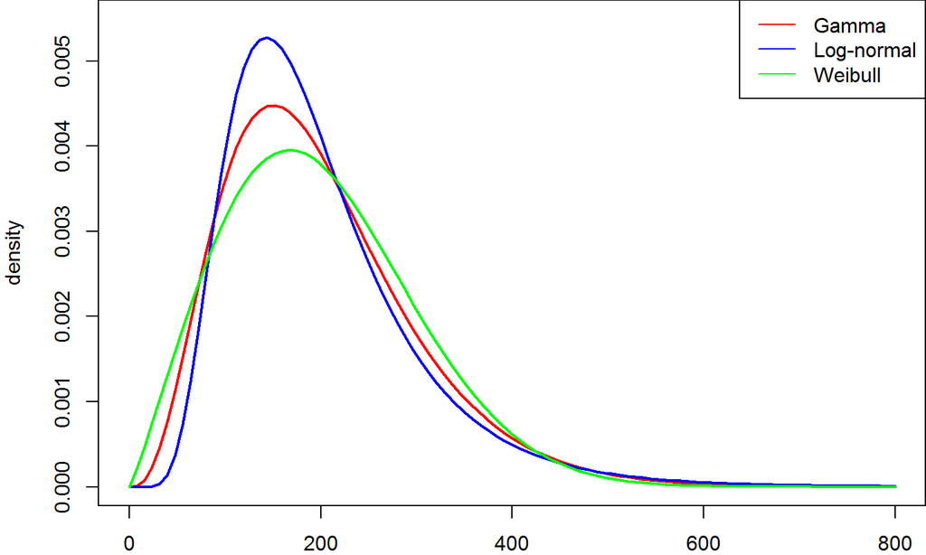

## Which distribution?

### Excessive zeros

Mixture of Bernoulli process (0/1) and exposure distribution

**Zero-inflated models**

- Zeros may arise from Bernoulli process or exposure distribution
- Zeros modelled as “true” and “apparent” zeros

**Hurdle models**

- Zeros only arise from Bernoulli process
- Zeros and non-zeros modelled as two separate processes

## Which distribution?

### Excessive zeros

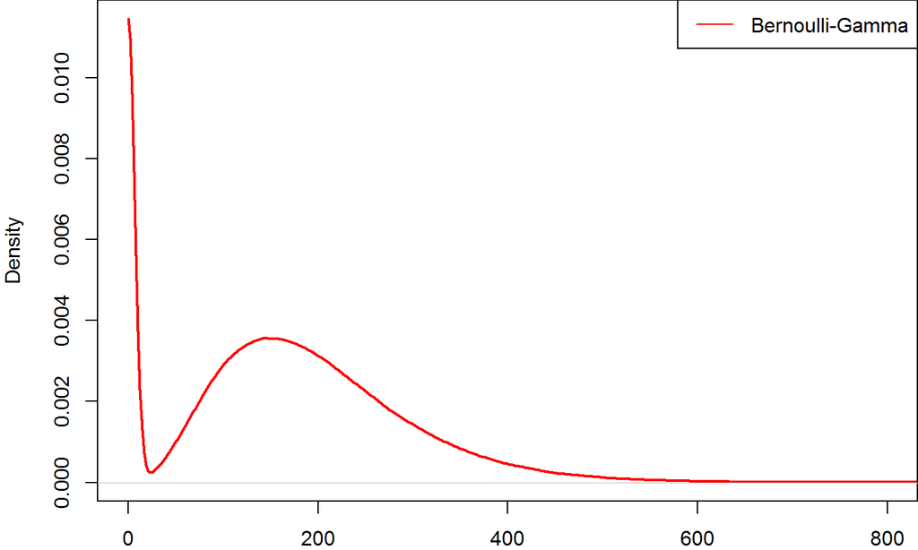

## Individual observations

## Individual observations

### Import data

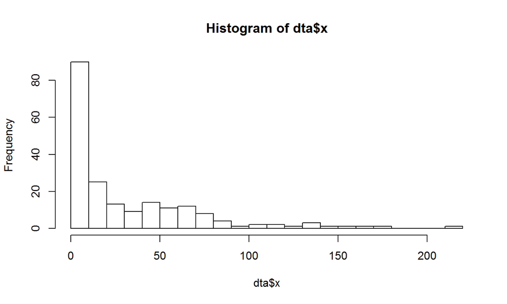

```r
dta <- read.csv("consumption.csv")
hist(dta$x, breaks = 20)
```

## Individual observations

### Bootstrap > PAF

\[PAF=\frac{\sum{P(x)RR(x)}-\sum{P'(x)RR(x)}}{\sum{P(x)RR(x)}}\] \[P(x)=1/n\]

```r
rr_fun <- rcsplineFunction(attr(fit_crc$model[[2]], "parms"), coef(fit_crc))
PRR <- mean(exp(rr_fun(dta$x)))
(PRR - 1) / PRR
```

```
## [1] 0.03224897
```

## Individual observations

### Fitting distributions

**Motivation**

- Smoothing
- Generalisability
- Mathematical ease
- Computational ease

**Methods**

- Method of moments
- Maximum likelihood

## Individual observations

### Method of moments

```r
args(dgamma)
```

```
## function (x, shape, rate = 1, scale = 1/rate, log = FALSE)
## NULL
```

\[E[X] = \alpha/\beta\]

\[Var(X) = \alpha / \beta^2 \]

\[\iff\]

\[\beta = E[X] / Var(X)\]

\[\alpha = E[X] * \beta\]

## Individual observations

### Method of moments

```r
m <- mean(dta$x)
v <- var(dta$x)
b <- m / v
a <- m * b
c(a, b)
```

```
## [1] 0.63778702 0.02040918
```

```r
c(m, a / b)
```

```
## [1] 31.25 31.25
```

```r
c(v, a / b^2)
```

```
## [1] 1531.173 1531.173
```

## Individual observations

### Method of moments

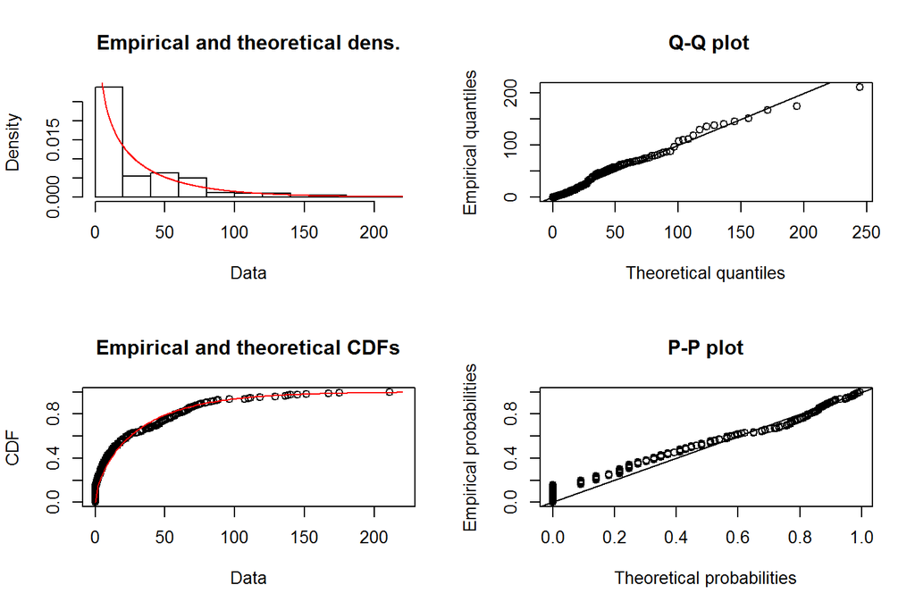

## Individual observations

### Method of moments > PAF

```r
int <-
  integrate(
    function(x)
      dgamma(x, fit_mme$`estimate`[1], fit_mme$`estimate`[2]) *
      exp(rr_fun(x)),
    lower = 0,
    upper = Inf)
PRR <- int$value
(PRR - 1) / PRR
```

```
## [1] 0.03175991
```

## Individual observations

### Maximum likelihood

```r
dta2 <- dta$x
dta2[dta2 == 0] <- 1e-2
fit_mle <- fitdistrplus::fitdist(dta2, dgamma, "mle")
fit_mle
```

```
## Fitting of the distribution ' gamma ' by maximum likelihood
## Parameters:
##         estimate  Std. Error
## shape 0.38273119 0.030772349
## rate  0.01225496 0.001698539
```

## Individual observations

### Maximum likelihood

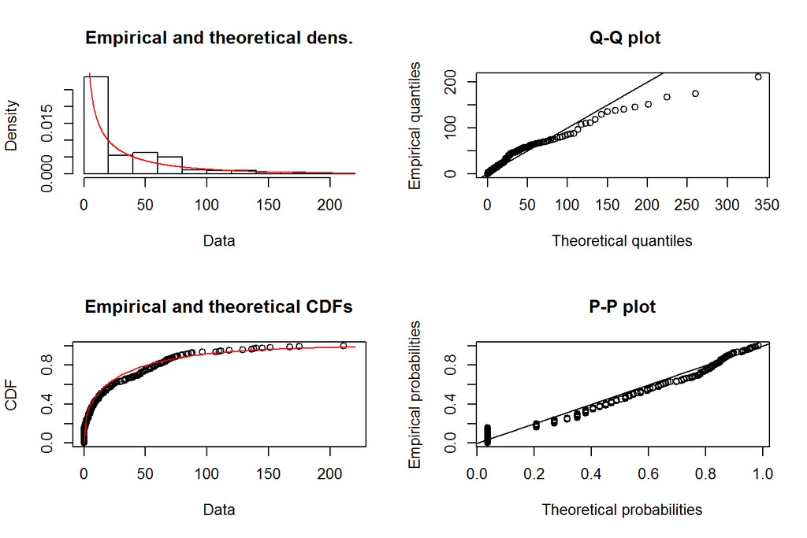

## Individual observations

### Maximum likelihood > PAF

```r
int <-
  integrate(
    function(x)
      dgamma(x, fit_mle$`estimate`[1], fit_mle$`estimate`[2]) *
      exp(rr_fun(x)),
    lower = 0,
    upper = Inf)
PRR <- int$value
(PRR - 1) / PRR
```

```
## [1] 0.03574357
```

## Individual observations

### Maximum likelihood (bis)

```r
library(flexsurv)
fit_mle2 <-
  fitdistrplus::fitdist(
    dta2,
    dgengamma,
    "mle",
    start = function(d)
      list(
        mu = mean(d),
        sigma = sd(d),
        Q = 0))
fit_mle2
```

```
## Fitting of the distribution ' gengamma ' by maximum likelihood
## Parameters:
##       estimate Std. Error
## mu    4.042400  0.1820763
## sigma 1.110498  0.1273631
## Q     2.697479  0.3893348
```

## Individual observations

### Maximum likelihood (bis)

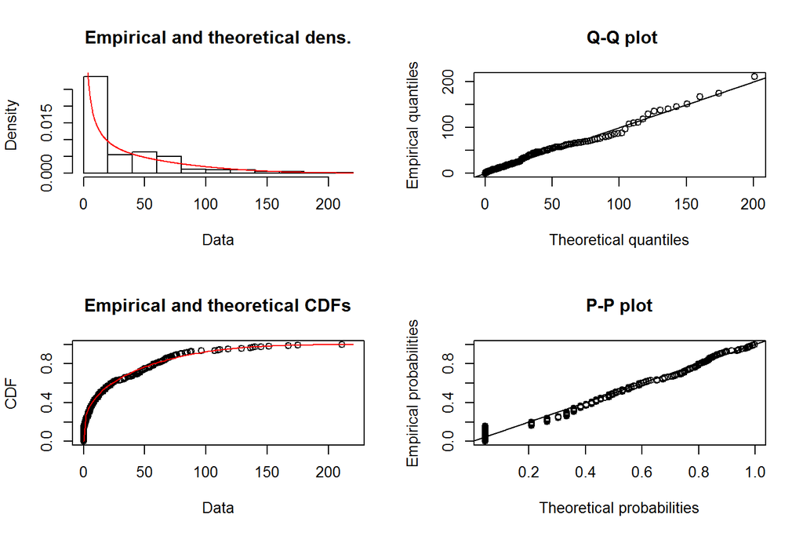

## Individual observations

### Maximum likelihood (bis) > PAF

```r
int <-
  integrate(
    function(x)
      dgengamma(
        x,
        fit_mle2$`estimate`[1],
        fit_mle2$`estimate`[2],
        fit_mle2$`estimate`[3]) *
      exp(rr_fun(x)),
    lower = 0,
    upper = Inf)
PRR <- int$value
(PRR - 1) / PRR
```

```
## [1] 0.03199674
```

## Individual observations

### Summary

|  | PAF | Cases | Deaths | DALY |
| --- | --- | --- | --- | --- |
| Bootstrap | 0.0322 | 286 | 120 | 1847 |
| MOM | 0.0318 | 281 | 118 | 1819 |
| MLE1 | 0.0357 | 317 | 133 | 2047 |
| MLE2 | 0.0320 | 284 | 119 | 1833 |

## Quantiles

## Quantiles

### Motivating example

EFSA data on red meat consumption in Belgium

| mean | P5 | P10 | P50 | P95 | P975 | P99 | SD |
| --- | --- | --- | --- | --- | --- | --- | --- |
| 42.79 | 0 | 0 | 19.05 | 146.8 | 181.4 | 248.75 | 65.87 |

## Quantiles

### Method of moments

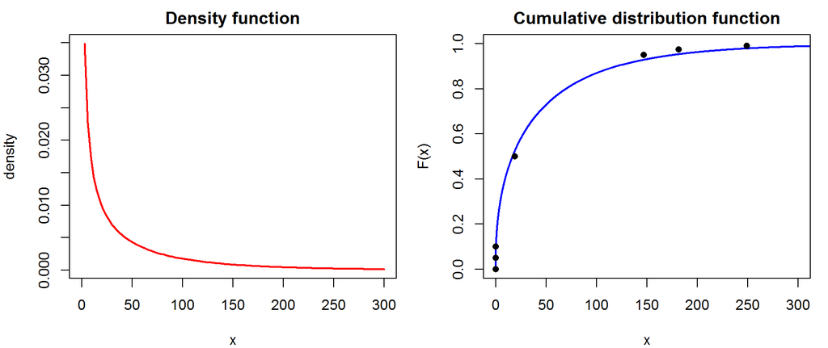

## Quantiles

### Optimization

Find a distribution that minimizes squared distance between observed and fitted quantiles

```r
## calculate sum of squared differences
f_gamma <-
function(par, p, q) {
  qfit <- qgamma(p = p, shape = par[1], rate = par[2])
  return(sum((qfit - q)^2))
}

## optimize
optim_gamma <-
function(p, q) {
  optim(par = c(1, 1), fn = f_gamma, p = p, q = q)
}
```

## Quantiles

### Optimization

```r
## find best fit
p <- c(0.05, 0.10, 0.50, 0.95, 0.975, 0.99)
fit <- optim_gamma(p = p, q = unlist(quant[1, 2:7]))
fit
```

```
## $par
## [1] 0.52763523 0.01381648
##
## $value
## [1] 50.69343
##
## $counts
## function gradient
##       97       NA
##
## $convergence
## [1] 0
##
## $message
## NULL
```

## Quantiles

### Optimization

Best fitting Gamma distribution

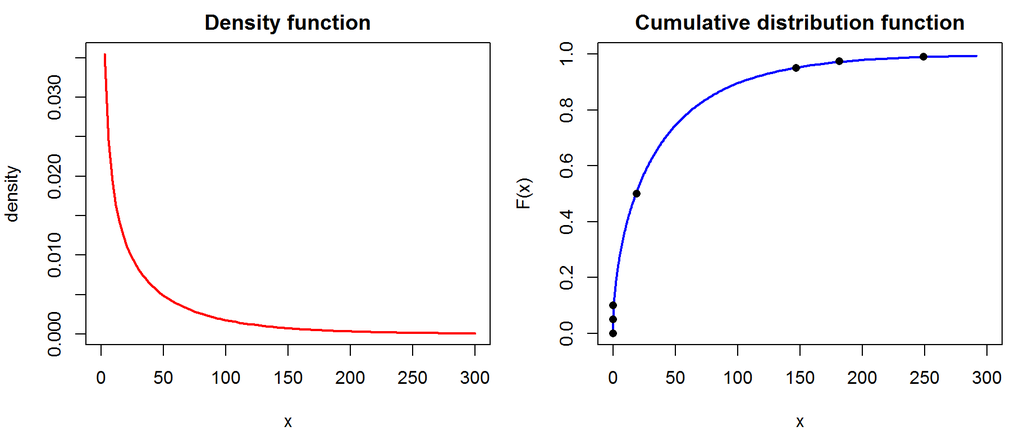

## Quantiles

### Optimization

|  | mean | P5 | P10 | P50 | P95 | P975 | P99 | SD |
| --- | --- | --- | --- | --- | --- | --- | --- | --- |
| observed | 42.79000 | 0.0000000 | 0.0000000 | 19.05000 | 146.8000 | 181.4000 | 248.7500 | 65.87000 |
| MOM | 42.79000 | 0.0629442 | 0.3259071 | 16.47898 | 174.5139 | 232.2550 | 311.5919 | 65.87000 |
| optim | 38.18883 | 0.1978381 | 0.7395386 | 18.19534 | 143.9096 | 187.2145 | 246.0642 | 52.57381 |

## Quantiles

### Optimization > PAF

|  | PAF | Cases | Deaths | DALY |
| --- | --- | --- | --- | --- |
| MOM | 0.0529 | 469 | 197 | 3032 |
| OPTIM | 0.0433 | 383 | 161 | 2479 |